# Trustworthiness of New York City Subway System

Author

Ernest Giahyue, Lawrenz Pacayo, Sean Smolyanskiy, Yusuf Ozaydin

Published

December 7, 2025

# Introduction:

Millions of New Yorkers rely on public transportation. Because of this, the transit system must be safe and reliable; however, public safety in the MTA has been a problem affecting New Yorkers. This project examines patterns of crime across NYC, with a particular focus on crime in the subway system, subway-related incidents such as delays, and how these factors may be connected. We analyze overall citywide crime trends, explore whether subway incidents correlate with higher crime levels, whether they relate to street-level crime, and map where subway shootings have occurred to understand their geographic distribution and impact. Additionally, we compare our findings with traffic accident data to consider driving as a safer alternative to the metro. Overall, our analysis shows that subway incidents are relatively rare, typically under 100 per month, and mostly mechanical. We find only a weak relationship between delays and subway crime, suggesting that incidents do not necessarily signal unsafe conditions. However, stations in higher-crime neighborhoods tend to experience more transit-related crime, indicating that subway safety often reflects broader community patterns. Finally, when comparing transit safety to driving, the data suggest that waiting for a train is generally safer than driving.

# Research Questions:

How does the MTA’s safety and reliability compare to the city’s overall safety? Beyond that, how often do incidents and delays happen? Is there a correlation between incidents and subway crime? Are certain boroughs safer than others? Is driving a safer alternative to the subway?

# Discuss Your Data Sources:

## MTA Subway Major Incidents

[Data Link](https://catalog.data.gov/dataset/mta-subway-major-incidents-beginning-2025)

The data used for this analysis is subway incidents, including mechanical and electrical failures, over time. The data was collected from data.gov and is also the original source of the data. Data.gov provides publicly accessible pre-processed data that will be used for this project. The original publisher of the data is NY Open data. The original data is by the city of New York and collected by MTA every time an incident had to be addressed in the subway system that caused 50 or more trains to be delayed. The data.gov link provides access to the original source. The only data that may be missing from this data set are mechanical incidents in the subway that have been left unnoticed and unresolved. Additionally, Incidents that caused less than 50 trains to be delayed may not have been reported on this data set. The data may be biased because some subway stations may be better maintained and therefore have more problems identified and reported, but overall the dataset is credible.

## MTA Major Felonies

[Data Link](https://data.ny.gov/Transportation/MTA-Major-Felonies/yeek-jhmu/about_data)

The dataset used for this analysis is the MTA Major Felonies dataset, which contains monthly counts of arrests for major felony offenses occurring on property operated by the Metropolitan Transportation Authority (MTA), including NYCT subways, the Staten Island Railway, Metro-North Railroad, and the Long Island Rail Road. Major felonies include murder, rape, robbery, felony assault, burglary, grand larceny, and grand larceny auto, as defined by New York State Penal Law. The data are compiled monthly by two law enforcement agencies: the NYPD Transit Bureau for NYCT property and the MTA Police Department for the remaining transit systems. If multiple offenses occur in a single incident, only the most serious felony is recorded, and attempted crimes are generally classified as completed offenses. This dataset is published as part of the MTA’s open data transparency initiative and may be revised slightly if crimes are reported after the monthly cutoff. The file used in this project is a direct public release from the MTA and has not undergone third-party preprocessing beyond standard publication formatting. In addition to felony counts, the dataset includes a standardized metric, Crimes per Million Riders, calculated from monthly ridership totals. Some data may be missing due to delayed reporting or because the dataset reflects arrests rather than all crimes committed. Grand larceny auto is excluded from NYCT because vehicles are not present in subway station areas. Potential biases include variation in enforcement practices across transit systems and differences in ridership volume, both of which influence arrest counts and crime rate calculations. A complete data dictionary for the dataset is provided in the appendix, including variable names, data types, and descriptions for all key fields: Month, Agency, Police Force, Felony Type, Felony Count, and Crimes per Million Riders.

## Traffic Accidents

The dataset used for this analysis is the NYC Motor Vehicle Collisions – Crashes dataset, which contains detailed records of traffic crashes in New York City. It is published through the NYC Open Data portal by the New York City Police Department (NYPD). It documents the date, time, location, contributing factors, and number of injuries and fatalities associated with each reported collision. The source and dataset access page is: [Data Link](https://data.cityofnewyork.us/Public-Safety/Motor-Vehicle-Collisions-Crashes/h9gi-nx95/about_data) The NYPD collects data at the scene of each reported motor vehicle collision using standardized police accident reports. These reports are completed when officers respond to crashes involving injury, death, or significant property damage, and the records are subsequently entered into the city’s open data system. The file used in this project is a direct public release from NYC Open Data and has not undergone third-party preprocessing beyond standard formatting for public access. Some data may be missing due to unreported minor collisions, incomplete officer reports, or imprecise geocoding. Potential biases include underreporting in low-severity crashes and variation in reporting practices by location or time of day. A complete data dictionary describing all variables used in this dataset is provided in the appendix.

## City Wide Crime

[Data Link](https://www.nyc.gov/site/nypd/stats/crime-statistics/historical.page)

The second data set used is Citywide Seven Major Felony Offenses from 2000 to 2024. The URL below returned several versions of the data, but the Excel version provided a more straightforward analysis of the number and types of incidents from 2000 to 2024. It was published by the NYPD via the “Historical Crime Data” page. The table reports annual citywide counts for the seven major felony categories plus the “Total Seven Major Felony Offenses” row for each year. The table is compiled and released by the NYPD, and all of these are internal NYPD data systems that capture complaint, arrest, and follow-up information. The dataset covers calendar years from 2000 to 2024, but for my chart, I narrowed it to 2019-2024 to align with the most recent period shown in my MTA chart. These incidents occur across all precincts and boroughs and include all NYPD-reported index crimes in the seven categories, not just those in transit. There weren’t any blank cells, indicating no missing data. A potential bias in this dataset could stem from changes in law, NYPD policy, or coding rules, which can alter the reported numbers even if the underlying behavior remains constant.

## New York City Map (Subway Stations and Shootings)

[Shootings Link](https://catalog.data.gov/dataset/nypd-shooting-incident-data-historic)

[Stations Link](https://catalog.data.gov/dataset/mta-subway-stations) The MTA Subway Stations dataset and the NYPD Shooting Incident Data. Combining these sources provides the geographic station points and the incident-level shooting records needed to examine the relationship between subway infrastructure and nearby violent incidents within a 40-meter radius of each station. The first dataset is from the Metropolitan Transportation Authority (MTA) and includes the location and attribute information for every subway station in New York City. This was downloaded from the official MTA Open Data Portal, labeled “MTA_Subway_Stations.csv”. Contains fields labeled as latitude, longitude, station names, lines served, and borough identifiers. The dataset is maintained by the MTA’s Geographic Information System (GIS) and transit planning teams, who record and update the station points through the GIS systems to reflect changes in service patterns, infrastructure updates, or newly opened stations. This dataset covers stations across all five boroughs and is periodically updated to support public transit planning, mapping tools, and operational transparency. The dataset was exported directly with no third-party modifications; however, we filtered out any latitudes or longitudes that were missing. This dataset is mostly reliable; the only bias is that a single point represents stations. A single point representing a multi-platform station with multiple entrances and exits represents a central location rather than all access points. The second dataset used is the NYPD Shooting Incident Data, published through the NYC Open Data portal. This dataset, labeled as NYPD_Shooting_Incident_Data_Historic.csv, includes every confirmed shooting incident recorded in New York City from 2006 to the present. Each row represents an individual shooting and includes variables such as the approximate location, date, and time, victim and perpetrator characteristics, and police jurisdiction information. The NYPD collects this data through official police reports, which also include the coordinates based on the address. The file used in this project was taken directly from the portal with no modifications. This dataset holds potential biases; some locations are imprecise due to geocoding limitations. The dataset only includes shootings with confirmed victims; if shots were fired and no one got hurt, it would not be recorded in the data. Despite these limitations, the dataset remains a comprehensive, publicly available source of gun violence data in the city.

# Analysis

## Subway Crime Data

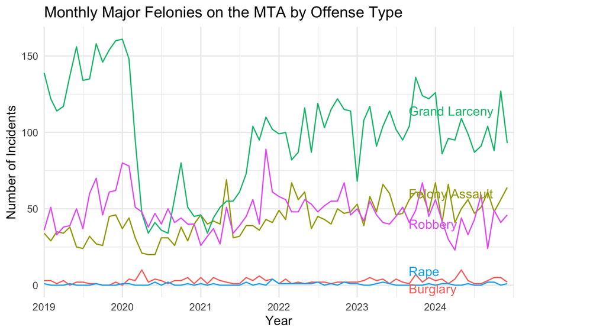

```r
library(tidyverse)
library(lubridate)
library(ggrepel)

mta_final_crime <- felonies_df %>% clean_names()

top_offenses <- mta_final_crime %>%
  mutate(date = mdy(month)) %>%
  filter(year(date) <= 2024) %>%
  count(felony_type, wt = felony_count, name = "total") %>%
  slice_max(total, n = 5) %>%
  pull(felony_type)

mta_by_offense_month <- mta_final_crime %>%
  mutate(
    date       = mdy(month),
    year_month = floor_date(date, unit = "month"),
    offense    = if_else(felony_type %in% top_offenses,
                         felony_type,
                         "Other")
  ) %>%
  filter(
    year(date) <= 2024,
    offense != "Other"
  ) %>%
  group_by(year_month, offense) %>%
  summarise(
    total = sum(felony_count, na.rm = TRUE),
    .groups = "drop"
  )

# pick the x-position for labels
label_date <- as.Date("2023-06-01")

# IMPORTANT: rebuild label_points from mta_by_offense_month
label_points <- mta_by_offense_month %>%
  group_by(offense) %>%
  mutate(dist = abs(as.numeric(year_month - label_date))) %>%
  slice_min(dist, n = 1, with_ties = FALSE) %>%
  ungroup() %>%
  select(year_month, total, offense, dist)




ggplot(mta_by_offense_month, aes(x = year_month, y = total, color = offense)) +
  geom_line() +
  geom_text_repel(
    data = label_points,
    aes(x = year_month, y = total, label = offense),
    nudge_x = 90,
    direction = "y",
    hjust = 0,
    segment.color = NA,
    show.legend = FALSE
  ) +
  scale_x_date(
    date_labels = "%Y",
    date_breaks = "1 year",
    expand = c(0, 0)
  ) +
  coord_cartesian(
    xlim = c(as.Date("2019-01-01"), as.Date("2024-12-31")),
    clip = "off"
  ) +
  theme_minimal() +
  theme(
    legend.position = "none",
    plot.margin = margin(5.5, 80, 5.5, 5.5)
  ) +
  labs(
    title = "Monthly Major Felonies on the MTA by Offense Type",
    x = "Year",
    y = "Number of Incidents"
  )
```

The Monthly Major Felonies on the MTA by Offense Type displayed the number of incidents over time from 2019 to 2024. Shockingly, the number of incidents was extremely low, given that over 8 million people live in NYC. At first glance, you may think based on the plots that the felonies occur at a high rate, but compared to the citywide crime chart, this isn’t true. In fact, the highest number of incidents recorded was just above 150, which was for grand larceny. This takes place right before COVID-19 spiked, and as you can see in the visual, the number starts to decrease significantly after the COVID-19 outbreak. We then see a trend in which felony types rise again once residents return to in-person work and school, right around mid-2021. Based on the numbers, we can assume that riding the MTA in NYC is much safer than many think. Now, is it safer than other ways of transportation? Like driving, for example.

## Felonies Per Million Riders

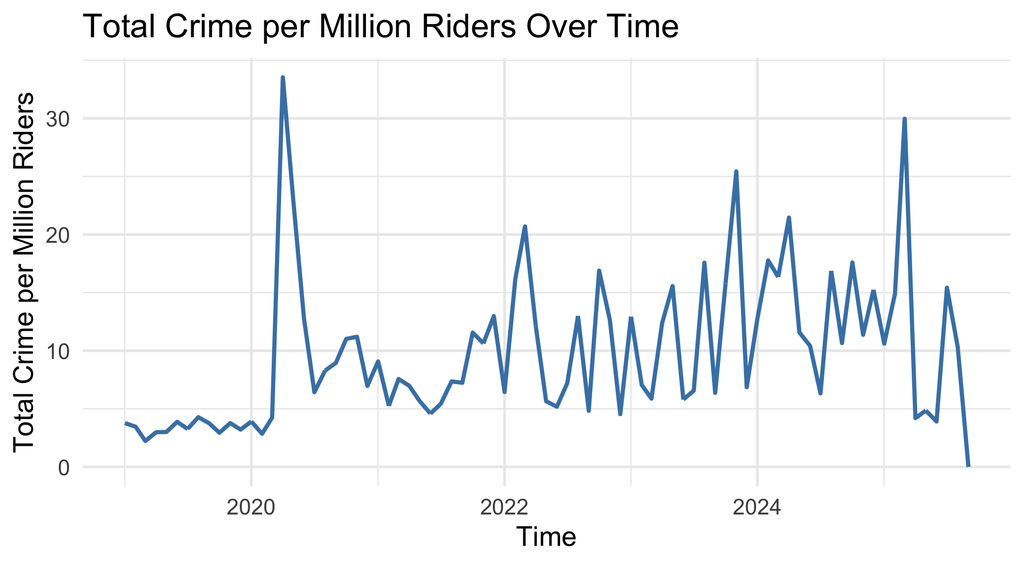

```r
chart2 <- ggplot(cleaned_felonies_df, aes(x = date, y = total_crimes_per_million)) +
    geom_line(color = "steelblue", size = 1) +
    #geom_point(color = "darkred", size = 2) +
    labs(
        title = "Total Crime per Million Riders Over Time",
        x = "Time",
        y = "Total Crime per Million Riders"
    ) +
    theme_minimal(base_size = 14)
chart2
```

## Total Subway Incidents

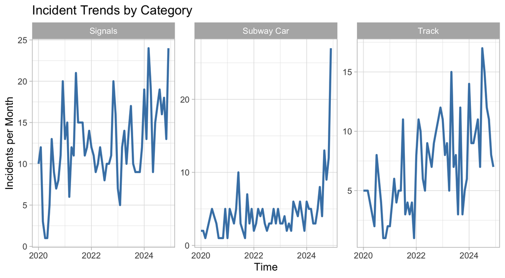

```r
chart3 <- ggplot(df_summary, aes(x = as.Date(month), y = total_incidents)) +
    geom_line(color = "steelblue", size = 1) +
    facet_wrap(~ category, scales = "free_y") +
    labs(
        title = "Incident Trends by Category",
        x = "Time",
        y = "Incidents per Month"
    ) +
    theme_light()
chart3
```

## Crime and Incidents Correlation

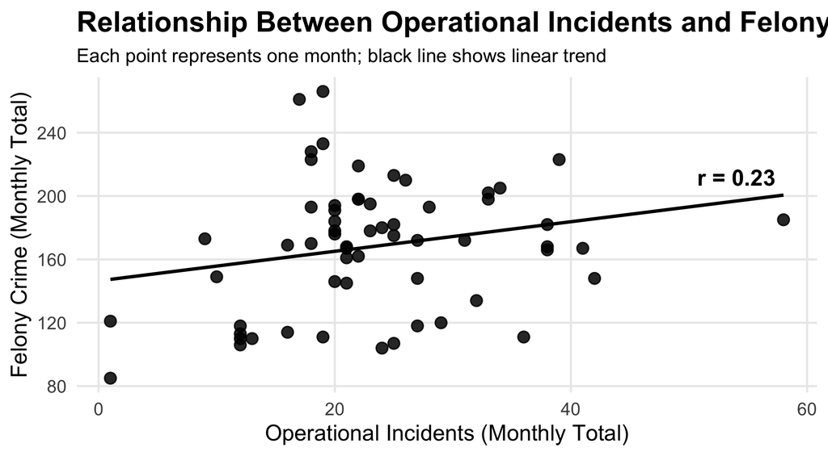

```r
# ============================
# 5. Final Scatterplot (NO COVID) + Save
# ============================

# ---- Correlation value ----
r_val <- round(cor(ci_scatter$incidents, ci_scatter$crime, use = "complete.obs"), 2)

# ---- Fit regression for precise right-edge annotation ----
fit <- lm(crime ~ incidents, data = ci_scatter)
x_r  <- max(ci_scatter$incidents, na.rm = TRUE)
y_r  <- predict(fit, newdata = data.frame(incidents = x_r))

# ---- Build plot object ----
p_scatter_polished <- ggplot(ci_scatter, aes(x = incidents, y = crime)) +
    geom_point(size = 3, alpha = 0.85) +
    geom_smooth(method = "lm", se = FALSE, linewidth = 1, color = "black") +

    # ---- r-value at far right of regression line ----
annotate(
    "text",
    x = x_r,
    y = y_r,
    label = paste0("r = ", r_val),
    hjust = 1.1,    # pull slightly left from the edge
    vjust = -0.6,   # lift slightly above the line
    size = 5,
    fontface = "bold",
    color = "black"
) +

    labs(
        title = "Relationship Between Operational Incidents and Felony Crime (NYCT)",
        subtitle = "Each point represents one month; black line shows linear trend",
        x = "Operational Incidents (Monthly Total)",
        y = "Felony Crime (Monthly Total)"
    ) +

    theme_minimal(base_size = 14) +
    theme(
        plot.title = element_text(face = "bold", size = 18),
        plot.subtitle = element_text(size = 12),
        legend.position = "none",
        panel.grid.minor = element_blank()
    )
p_scatter_polished
```

This scatterplot examines the relationship between monthly operational incidents on the MTA and monthly felony crime counts on NYCT property, with each point representing one month. The fitted regression line shows a positive but weak correlation between incidents and crime (r = 0.23), indicating that months with more delays and infrastructure-related incidents tend to be associated with slightly higher reported felony counts, though the relationship is not strong.

In the context of our research question, this chart suggests that operational breakdowns alone do not appear to be a dominant driver of subway crime levels. While the upward slope suggests an association, the wide vertical spread of points indicates substantial variability in crime even during months with similar incident totals. This indicates that other social, economic, and ridership-related factors likely play a larger role in shaping subway crime patterns than delays by themselves.

This chart also contributes to the broader comparison of MTA safety versus overall city safety. If incidents were a primary cause of increased subway crime, we would expect a much tighter relationship. Instead, the weak correlation suggests that subway reliability issues and crime risk are only loosely connected, reinforcing the need to examine additional factors such as borough-level patterns, ridership volume, and street-level crime trends. These findings motivate the next stages of analysis, including geographic mapping of shootings and comparison with citywide motor vehicle accident data to evaluate whether driving represents a safer alternative to public transit.

## Subway Shootings Map

```r
# ----------------------------------------------------------
# SHOOTINGS & STATIONS AS sf
# ----------------------------------------------------------
shoot_sf <- shoot %>%
  filter(!is.na(Latitude), !is.na(Longitude)) %>%
  st_as_sf(coords = c("Longitude", "Latitude"),
           crs = 4326, remove = FALSE)

stations_sf <- mta_locations %>%
  filter(!is.na(`GTFS Latitude`), !is.na(`GTFS Longitude`)) %>%
  st_as_sf(coords = c("GTFS Longitude", "GTFS Latitude"),
           crs = 4326, remove = FALSE)

# ----------------------------------------------------------
# STATION BUFFERS & SUBWAY SHOOTINGS (within 40m)
# ----------------------------------------------------------
shoot_3857    <- st_transform(shoot_sf, 3857)
stations_3857 <- st_transform(stations_sf, 3857)

stations_buf <- st_buffer(stations_3857, dist = 40)

shootings_subway_sf <- st_join(
  shoot_3857,
  stations_buf,
  join = st_within,
  left  = FALSE
)

# counts per station for subway shootings
shoot_counts <- shootings_subway_sf %>%
  st_drop_geometry() %>%
  group_by(`Stop Name`, Line, `Daytime Routes`, Borough) %>%
  summarise(shooting_count = n(), .groups = "drop")

stations_with_counts <- stations_sf %>%
  left_join(
    shoot_counts,
    by = c("Stop Name", "Line", "Daytime Routes", "Borough")
  ) %>%
  mutate(
    shooting_count = ifelse(is.na(shooting_count), 0L, shooting_count)
  )

# ----------------------------------------------------------
# STREET SHOOTINGS (NOT NEAR SUBWAYS)
# ----------------------------------------------------------
street_shoot_sf <- shoot_sf %>%
  filter(!(INCIDENT_KEY %in% shootings_subway_sf$INCIDENT_KEY))

boro_stats <- street_shoot_sf %>%
  st_drop_geometry() %>%
  count(BORO, name = "street_shootings")

# map BORO names to county names
boro_map <- c(
  "BRONX"         = "Bronx",
  "BROOKLYN"      = "Kings",
  "MANHATTAN"     = "New York",
  "QUEENS"        = "Queens",
  "STATEN ISLAND" = "Richmond"
)

boro_stats <- boro_stats %>%
  mutate(COUNTY_NAME = recode(BORO, !!!boro_map))

# ----------------------------------------------------------
# NYC BOROUGHS + JOIN STREET SHOOTING COUNTS
# ----------------------------------------------------------
ny_boroughs <- counties(state = "NY", cb = TRUE, class = "sf") %>%
  filter(NAME %in% c("New York", "Kings", "Bronx", "Queens", "Richmond"))

ny_boroughs_shoot <- ny_boroughs %>%
  left_join(boro_stats, by = c("NAME" = "COUNTY_NAME")) %>%
  # NEW: if a borough has no street shootings, set to 0 (e.g. Staten Island)
  mutate(street_shootings = ifelse(is.na(street_shootings), 0L, street_shootings))

# we'll use this name in leaflet instead of boroughs_geo
boroughs_geo <- ny_boroughs_shoot

# ----------------------------------------------------------
# COLOR PALETTES
# ----------------------------------------------------------
# Stations: gray for 0, strong reds for 1+
nonzero_counts <- stations_with_counts$shooting_count[
  stations_with_counts$shooting_count > 0
]

pal_station <- colorNumeric(
  palette = colorRampPalette(c(
    "#FF7B7B",  # light red
    "#FF3B3B",  # solid red
    "#D71414",  # strong red
    "#8B0000"   # deep dark red
  ))(200),
  domain = nonzero_counts
)

zero_color <- "#A6AEC0"   # more visible bluish-gray for 0-shooting stations

# Boroughs: blue gradient for street shootings
pal_boro <- colorNumeric(
  palette = "Blues",
  domain  = boroughs_geo$street_shootings
)

# ----------------------------------------------------------
# LEAFLET MAP (WITH GROUP-CONTROLLED LEGENDS)
# ----------------------------------------------------------
map <- leaflet() %>%
  # addTiles() %>%
  addProviderTiles(providers$CartoDB.Positron) %>%

  # Blue borough borders + blue fill by street shootings
  addPolygons(
    data = boroughs_geo,
    fillColor = ~pal_boro(street_shootings),
    fillOpacity = 0.45,
    weight = 3,
    color = "#0A1D4D",   # dark navy blue border
    group = "Boroughs",
    label = ~paste0(NAME, ": ", street_shootings, " street shootings"),
    highlightOptions = highlightOptions(
      weight = 4,
      color = "#000000",
      fillOpacity = 0.6,
      bringToFront = TRUE
    )
  ) %>%

  # Station dots colored by subway shootings
  addCircleMarkers(
    data = stations_with_counts,
    radius = 6,
    fillColor = ~ifelse(
      shooting_count == 0,
      zero_color,
      pal_station(shooting_count)
    ),
    color = NA,
    stroke = FALSE,
    fillOpacity = 0.9,
    popup = ~paste0(
      "<b>", `Stop Name`, "</b><br>",
      "Lines: ", `Daytime Routes`, "<br>",
      "Borough: ", Borough, "<br>",
      "Subway shootings within 40m: ", shooting_count
    ),
    group = "Stations"
  ) %>%

  # Legend for borough street shootings (blue)
  addLegend(
    position  = "bottomright",
    pal       = pal_boro,
    values    = boroughs_geo$street_shootings,
    title     = "Street shootings per borough",
    opacity   = 0.8,
    className = "legend-boroughs"
  ) %>%

  # Legend for station subway shootings (red)
  addLegend(
    position  = "bottomleft",
    pal       = pal_station,
    values    = nonzero_counts,
    title     = "Subway shootings (within 40m)",
    opacity   = 0.8,
    className = "legend-stations"
  ) %>%

  addLayersControl(
    overlayGroups = c("Boroughs", "Stations"),
    options = layersControlOptions(collapsed = FALSE)
  )

# ----------------------------------------------------------
# JS: HIDE/SHOW LEGENDS WITH THEIR GROUPS
# ----------------------------------------------------------
htmlwidgets::onRender(
  map,
  "
  function(el, x) {
    var map = this;
    var boroughLegend = document.querySelector('.legend-boroughs');
    var stationLegend = document.querySelector('.legend-stations');

    // start visible (since both groups are checked by default)
    if (boroughLegend) boroughLegend.style.display = 'block';
    if (stationLegend) stationLegend.style.display = 'block';

    map.on('overlayadd', function(e) {
      if (e.name === 'Boroughs' && boroughLegend) {
        boroughLegend.style.display = 'block';
      }
      if (e.name === 'Stations' && stationLegend) {
        stationLegend.style.display = 'block';
      }
    });

    map.on('overlayremove', function(e) {
      if (e.name === 'Boroughs' && boroughLegend) {
        boroughLegend.style.display = 'none';
      }
      if (e.name === 'Stations' && stationLegend) {
        stationLegend.style.display = 'none';
      }
    });
  }
  "
)
```

[interactive chart not shown]

## Overall NYC Crime

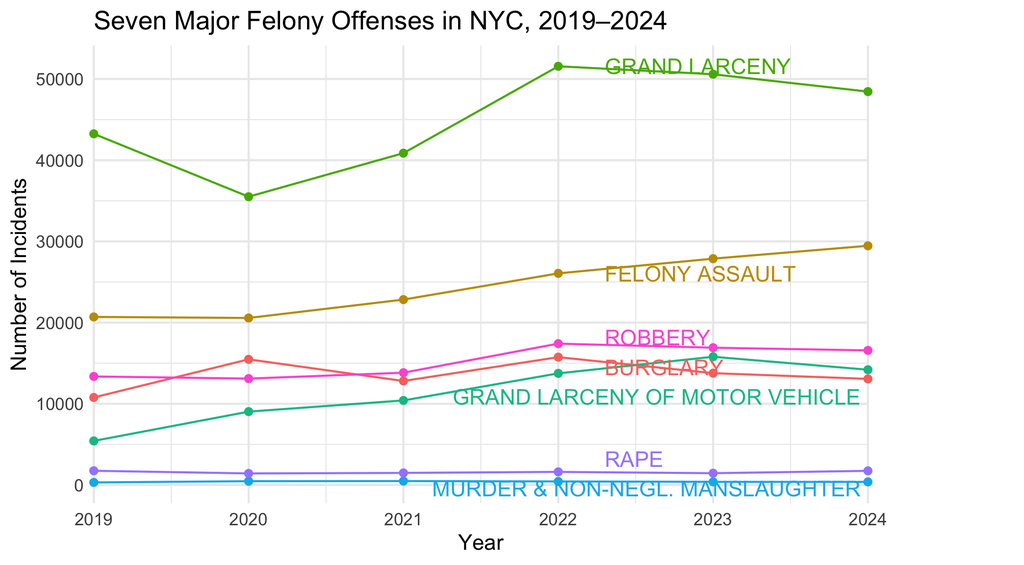

```r
label_year <- 2022

label_points_year <- crime_long %>%
  group_by(offense) %>%
  mutate(dist = abs(year - label_year)) %>%
  slice_min(dist, n = 1, with_ties = FALSE) %>%
  ungroup()

ggplot(crime_long, aes(x = year, y = total, color = offense)) +
  geom_line() +
  geom_point() +
  geom_text_repel(
    data = label_points_year,
    aes(x = year, y = total, label = offense),
    nudge_x = 0.3,
    direction = "y",
    hjust = 0,
    segment.color = NA,
    show.legend = FALSE
  ) +
  scale_x_continuous(
    breaks = 2019:2024,
    limits = c(2019, 2024),
    expand = c(0, 0)
  ) +
  coord_cartesian(clip = "off") +
  theme_minimal() +
  theme(
    legend.position = "none",
    plot.margin = margin(5.5, 80, 5.5, 5.5)
  ) +
  labs(
    title = "Seven Major Felony Offenses in NYC, 2019–2024",
    x = "Year",
    y = "Number of Incidents"
  )
```

## Traffic Accidents

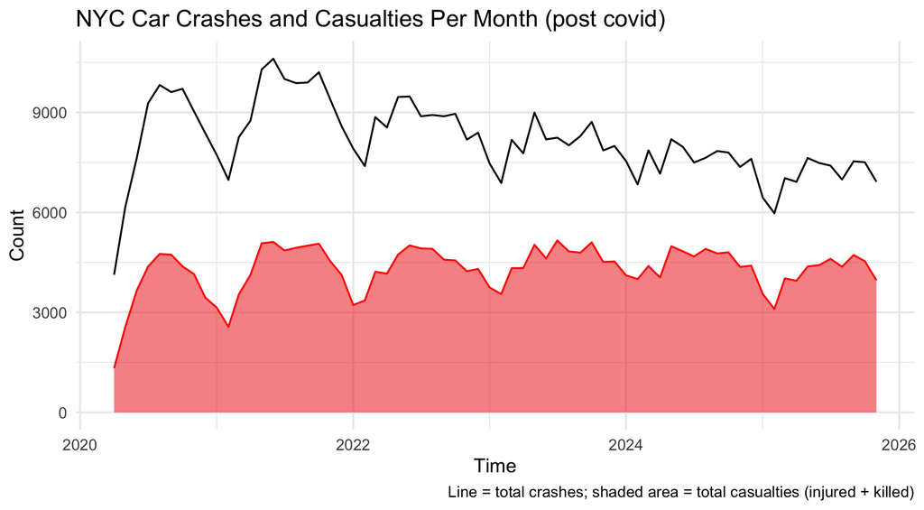

```r
ggplot(cleaned_crashes, aes(x = month)) +
    geom_area(aes(y = total_casualties),
              alpha = 0.5, fill = 'red2', color = 'red') +   # semi-transparent casualties area
    geom_line(aes(y = total_crashes)) +
    labs(
        title   = "NYC Car Crashes and Casualties Per Month (post covid)",
        x       = "Time",
        y       = "Count",
        caption = "Line = total crashes; shaded area = total casualties (injured + killed)"
    ) +
    theme_minimal()
```

To evaluate whether driving is a safer alternative to the subway, this chart shows monthly totals of motor vehicle crashes and total casualties (injuries + fatalities) in New York City during the post-COVID period. The black line represents the number of crashes per month, while the shaded red area captures the number of people physically harmed in those crashes. Together, these two measures provide a direct view of both the frequency and the severity of driving-related risk over time. The visualization reveals that thousands of traffic crashes occur every month, with casualty counts consistently in the several-thousand range, even after pandemic-related disruptions subsided. While there is month-to-month variation, the broader pattern shows that driving exposes residents to a persistent and substantial risk of physical injury or death, even during periods when crash totals decline slightly. This level of harm contrasts sharply with subway crime figures, where major felonies occur at much lower absolute levels relative to the number of trips taken. In the context of our broader research question: “Is driving a safer alternative to the subway?” This chart suggests that driving is far more likely to cause physical harm than riding the subway. While subway safety debates often focus on crime incidents, this comparison shows that transportation risk is not solely criminal but also physical. That car travel produces far more injuries than subway travel. When viewed alongside earlier charts showing relatively low monthly subway felony counts, this evidence challenges the perception that switching from public transit to driving necessarily improves personal safety.